```yaml
---
title: "Microclima: Mezcla Gaussiana (GMM) con Temperatura y Humedad — Ejemplo mínimo"
author: "FCFM–UNACH | Matemáticas Aplicadas"
date: "2025-08-26"
output:
  html_document:
    toc: true
    toc_float: true
    df_print: paged
  pdf_document: default
fontsize: 11pt
---
```

# Motivación

Una red pequeña de sensores mide **temperatura media** ($^\circ$C) y **humedad relativa** (%) en un valle con dos **microclimas** que coexisten:

1. **Húmedo-fresco** (sombra, cercanía a cuerpos de agua),
2. **Seco-cálido** (laderas soleadas).

En lugar de resumir todo con un solo promedio, modelamos $(\mathrm{Temp}, \mathrm{Hum})$ con un **Modelo de Mezcla Gaussiana (GMM)** de **dos componentes** y estimamos parámetros con **EM**. Empezamos con un **ejemplo mínimo** que permite **hacer cuentas a mano** y luego contrastamos con `mclust`.

# Formulación (2D) y algoritmo EM

Sea $X=(\text{Temp}, \text{Hum})\in\mathbb{R}^2$. Modelo:

$$p(x\mid\Theta)=\sum_{k=1}^{2}\pi_k\,\mathcal N\!\big(x\mid
\mu_k,\Sigma_k\big),\qquad
\pi_k>0,\ \ \pi_1+\pi_2=1.$$

- $\mu_k\in\mathbb{R}^2$: medias por componente,
- $\Sigma_k\in\mathbb{R}^{2\times 2}$: covarianzas.

Variables latentes $Z_i\in\{1,2\}$. **E-step** (responsabilidades/posteriores):

$$\gamma_{ik}=
\frac{\pi_k\,\phi_2(x_i;\mu_k,\Sigma_k)}
{\sum_{j=1}^2 \pi_j\,\phi_2(x_i;\mu_j,\Sigma_j)}.$$

**M-step**:

$$N_k=\sum_i\gamma_{ik},\quad
\pi_k^{new}=\frac{N_k}{N},\quad
\mu_k^{new}=\frac{1}{N_k}\sum_i\gamma_{ik}x_i,\quad
\Sigma_k^{new}=\frac{1}{N_k}\sum_i\gamma_{ik}(x_i-\mu_k^{new})(x_i-\mu_k^{new})^\top.$$

> Para cálculo manual usaremos $\Sigma_k$ **diagonal** (independencia entre Temp y Hum dentro de cada componente).

# Datos mínimos (6 observaciones)

Tomamos **N = 6** puntos. Usaremos humedad **normalizada** en $[0,1]$ (dividir entre 100) para que ambas variables estén en magnitudes comparables.

```r
# Temperatura (°C) y Humedad (%) → humedad en [0,1]
X_raw <- data.frame(
  Temp = c(20, 21, 24, 25, 28, 30),
  HumP = c(80, 78, 70, 65, 55, 50)  # porcentaje
)
X <- cbind(Temp = X_raw$Temp, Hum = X_raw$HumP/100)
DF <- data.frame(i = 1:nrow(X), X)
DF
```

```
##   i Temp  Hum
## 1 1   20 0.80
## 2 2   21 0.78
## 3 3   24 0.70
## 4 4   25 0.65
## 5 5   28 0.55
## 6 6   30 0.50
```

**Verdad terreno docente** (para evaluar ARI):

- **H** (Húmedo-fresco) para i = 1, 2
- **S** (Seco-cálido) para i = 3, 4, 5, 6

```r
truth <- factor(c("H","H","S","S","S","S"))
truth
```

```
## [1] H H S S S S
## Levels: H S
```

# Inicialización (intuitiva, diagonal)

- Pesos: $\pi_1=\pi_2=0.5$
- Medias:

  $$\mu_1=(21,\ 0.80),\quad \mu_2=(29,\ 0.52)$$
- Desv. estándar (por dimensión):

  $$\sigma_1=(1.5,\ 0.04),\quad \sigma_2=(2.0,\ 0.05)$$
- Covarianzas: $\Sigma_k=\mathrm{diag}(\sigma_{k,1}^2,\sigma_{k,2}^2)$.

```r
pi1 <- 0.5; pi2 <- 0.5
mu1 <- c(21, 0.80); mu2 <- c(29, 0.52)
sd1 <- c(1.5, 0.04); sd2 <- c(2.0, 0.05)
```

# E-step (una vuelta): responsabilidades $\gamma_{ik}$

Con $\Sigma$ diagonal:

$$\phi_2(x;\mu,\Sigma)=\prod_{d=1}^2
\phi\big(x^{(d)};\mu^{(d)},\sigma^{(d)}\big).$$

```r
# densidad 2D con covarianza diagonal
d2_diag <- function(x, mu, sd) dnorm(x[1], mu[1], sd[1]) * dnorm(x[2], mu[2], sd[2])

num1 <- apply(X, 1, function(x) pi1 * d2_diag(x, mu1, sd1))
num2 <- apply(X, 1, function(x) pi2 * d2_diag(x, mu2, sd2))
den  <- num1 + num2

gamma1 <- num1 / den
gamma2 <- 1 - gamma1

E_table <- data.frame(
  i     = 1:nrow(X),
  Temp  = X[,1],
  Hum   = X[,2],
  gamma_H = signif(gamma1, 4),  # comp 1 ~ Húmedo-fresco
  gamma_S = signif(gamma2, 4)   # comp 2 ~ Seco-cálido
)
E_table
```

```
##   i Temp  Hum   gamma_H   gamma_S
## 1 1   20 0.80 1.000e+00 4.653e-12
## 2 2   21 0.78 1.000e+00 3.065e-10
## 3 3   24 0.70 9.932e-01 6.754e-03
## 4 4   25 0.65 9.049e-03 9.910e-01
## 5 5   28 0.55 1.390e-13 1.000e+00
## 6 6   30 0.50 1.901e-20 1.000e+00
```

# M-step: actualización $(\pi,\mu,\Sigma)$

```r
N1 <- sum(gamma1); N2 <- sum(gamma2)
pi1_new <- N1/nrow(X); pi2_new <- N2/nrow(X)

mu1_new <- colSums(gamma1 * X) / N1
mu2_new <- colSums(gamma2 * X) / N2

# Covarianzas diagonales actualizadas
var1_new <- colSums(gamma1 * (X - matrix(mu1_new, nrow(X), 2, byrow=TRUE))^2) / N1
var2_new <- colSums(gamma2 * (X - matrix(mu2_new, nrow(X), 2, byrow=TRUE))^2) / N2
sd1_new  <- sqrt(var1_new); sd2_new <- sqrt(var2_new)

M_table <- data.frame(
  componente = c("1 (Húmedo-fresco)", "2 (Seco-cálido)"),
  N_k = c(N1, N2),
  pi_k = c(pi1_new, pi2_new),
  mu_Temp = c(mu1_new[1], mu2_new[1]),
  mu_Hum  = c(mu1_new[2], mu2_new[2]),
  sd_Temp = c(sd1_new[1], sd2_new[1]),
  sd_Hum  = c(sd1_new[2], sd2_new[2]),
  stringsAsFactors = FALSE
)

# redondear solo columnas numéricas
nums <- sapply(M_table, is.numeric)
M_table_round <- M_table
M_table_round[, nums] <- lapply(M_table_round[, nums], round, 4)
M_table_round
```

```
##          componente    N_k   pi_k mu_Temp mu_Hum sd_Temp sd_Hum
## 1 1 (Húmedo-fresco) 3.0023 0.5004 21.6715 0.7598  1.7053 0.0435
## 2   2 (Seco-cálido) 2.9977 0.4996 27.6665 0.5667  2.0577 0.0625
```

# Verificación: mejora de log-verosimilitud

```r
loglik <- function(X, p1, m1, s1, p2, m2, s2){
  dens1 <- apply(X, 1, function(x) d2_diag(x, m1, s1))
  dens2 <- apply(X, 1, function(x) d2_diag(x, m2, s2))
  sum(log(p1*dens1 + p2*dens2))
}

ll0 <- loglik(X, pi1,    mu1,    sd1,    pi2,    mu2,    sd2)
ll1 <- loglik(X, pi1_new,mu1_new,sd1_new,pi2_new,mu2_new,sd2_new)
c(ll_inicial = round(ll0, 4), ll_despues_EM = round(ll1, 4))
```

```
##    ll_inicial ll_despues_EM
##      -11.1845       -7.0536
```

# Visualización: responsabilidades (color) y clases

Coloreamos por $\gamma_{H}$ (probabilidad del componente 1) y mostramos las etiquetas verdaderas (H/S).

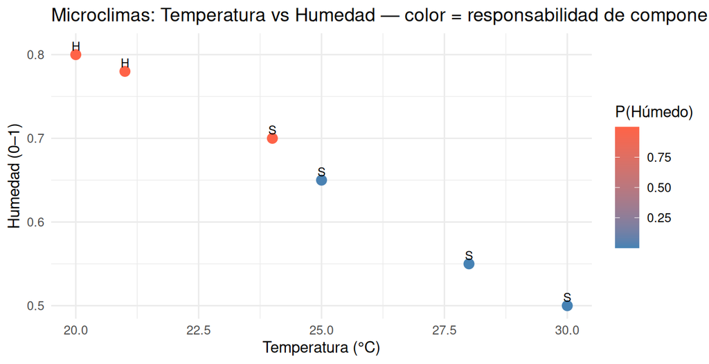

```r
library(ggplot2)

viz <- data.frame(DF, truth = truth, gammaH = gamma1)
ggplot(viz, aes(Temp, Hum)) +
  geom_point(aes(color = gammaH), size = 3) +
  geom_text(aes(label = truth), nudge_y = 0.01, size = 3) +
  scale_color_gradient(name = "P(Húmedo)", low = "steelblue", high = "tomato") +
  labs(title = "Microclimas: Temperatura vs Humedad — color = responsabilidad de componente H",
       x = "Temperatura (°C)", y = "Humedad (0–1)") +
  theme_minimal()
```

# Confirmación con `mclust` y ARI

```r
# install.packages("mclust")  # si hace falta
library(mclust)
fit <- Mclust(X, G = 1:3)         # selección de G por BIC
summary(fit)
```

```
## ----------------------------------------------------
## Gaussian finite mixture model fitted by EM algorithm
## ----------------------------------------------------
##
## Mclust VEV (ellipsoidal, equal shape) model with 2 components:
##
##  log-likelihood n df        BIC       ICL
##        8.521191 6 10 -0.8752133 -0.878048
##
## Clustering table:
## 1 2
## 4 2
```

```r
pred <- factor(fit$classification)
table(truth, pred)
```

```
##      pred
## truth 1 2
##     H 2 0
##     S 2 2
```

```r
ARI <- adjustedRandIndex(truth, pred)
ARI
```

```
## [1] -0.07142857
```

> `Mclust` iterará hasta converger y puede elegir $G=2$ para este caso; puede intercambiar las etiquetas de componente (label switching). ARI es invariante a este intercambio.

# (Opcional) Mapa simple con coordenadas de sensores

Si además de Temp y Hum tenemos **coordenadas** de los sensores, podemos mapear la **pertenencia** $\gamma_H$. Usamos coordenadas ficticias (km) para los 6 sensores y coloreamos por $\gamma_H$.

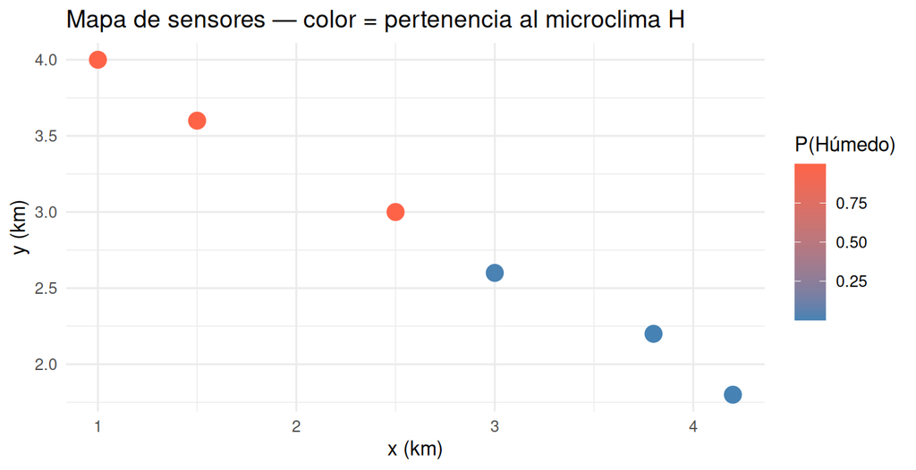

```r
# Coordenadas ficticias (x,y) para cada punto i=1..6
coords <- data.frame(
  i = 1:6,
  x = c(1.0, 1.5, 2.5, 3.0, 3.8, 4.2),
  y = c(4.0, 3.6, 3.0, 2.6, 2.2, 1.8)
)

mapdf <- merge(viz, coords, by = "i")
ggplot(mapdf, aes(x, y)) +
  geom_point(aes(color = gammaH), size = 4) +
  scale_color_gradient(name = "P(Húmedo)", low = "steelblue", high = "tomato") +
  labs(title = "Mapa de sensores — color = pertenencia al microclima H",
       x = "x (km)", y = "y (km)") +
  theme_minimal()
```

# Ejercicios sugeridos

1. Repite **E-step** con $(\pi,\mu,\Sigma)$ **actualizados** y verifica que la **log-verosimilitud** vuelve a subir.
2. Cambia la **inicialización** (por ejemplo $\pi_1=0.7$, $\pi_2=0.3$ o medias más cercanas) y discute el impacto en los puntos frontera $(24,0.70)$ y $(25,0.65)$.
3. Permite $\Sigma_k$ **no diagonal** (usa `Mclust` y compara BIC de modelos `EEE`, `VVV`, etc.).
4. Genera un **dataset sintético** mayor (p. ej. 150 puntos) con dos gaussianas 2D y repite todo: responsabilidades, log-verosimilitud vs iteraciones, ARI.
5. (Avanzado) Si tienes coordenadas reales, ajusta un **modelo espacial** para Temp/Hum (kriging u otro) y luego aplica GMM sobre los **predictores** locales.

**Notas rápidas**

- Normalizamos la humedad a $[0,1]$ para estabilidad numérica; si trabajas en %, ajusta las desviaciones.
- La tabla mínima usa $\Sigma$ diagonal para que el **cálculo manual** sea directo; `Mclust` puede seleccionar covarianzas completas según BIC.
- En visualizaciones usamos `size` (no `linewidth`) por compatibilidad con versiones de `ggplot2`.

Generen un **dataset sintético mayor** con control de solapamiento entre microclimas y gráficos listos para evaluación (BIC, ARI, fronteras)